# COVID-19 Model Iteration 3-a-1 Endogeneity Evaluation

The code for the assessment of endogeneity using the Gaussian Copula approach comes from

Hult, G. T. M., J. F. Hair, D. Proksch, M. Sarstedt, A. Pinkwart, & C. M. Ringle (2018). Addressing Endogeneity in International Marketing Applications of Partial Least Squares Structural Equation Modeling. Journal of International Marketing, 26(3), 1–21. https://doi.org/10.1509/jim.17.0151

# Test of non-normality

The Gaussian Copula approach can only be used if the independent variable in question is non-normally distributed.

```r
# Find out if independent (i.e., exogenous) variables are non-normally distributed
# If yes, Gaussian Copula approach can be used.
#Distrusting Beliefs
shapiro.test(model$construct_scores[,"Distrusting Beliefs"])
```

```
##
##  Shapiro-Wilk normality test
##
## data:  model$construct_scores[, "Distrusting Beliefs"]
## W = 0.95535, p-value = 3.861e-10
```

```r
lillie.test(model$construct_scores[,"Distrusting Beliefs"])
```

```
##
##  Lilliefors (Kolmogorov-Smirnov) normality test
##
## data:  model$construct_scores[, "Distrusting Beliefs"]
## D = 0.064678, p-value = 0.0001823
```

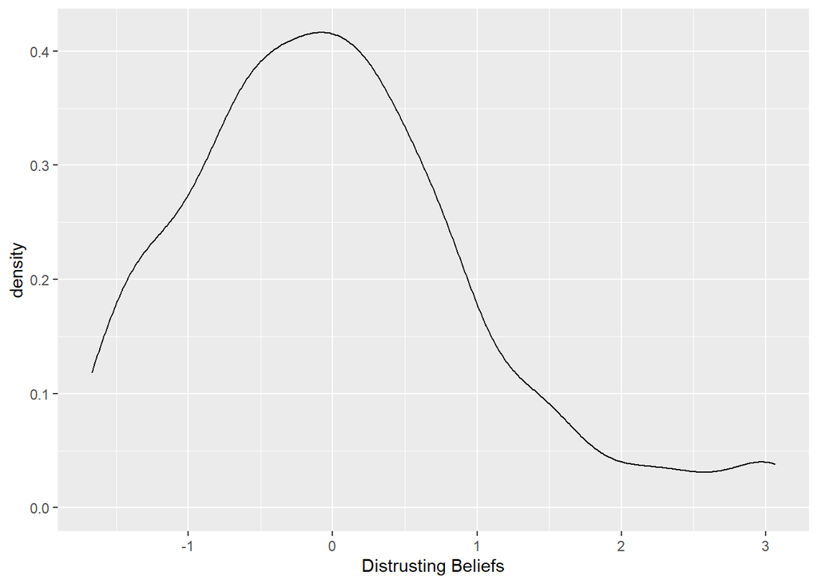

```r
ggplot(as.data.frame(model$construct_scores), aes(`Distrusting Beliefs`)) +
  geom_density()
```

```r
# Knowledge
shapiro.test(model$construct_scores[,"Knowledge"])
```

```
##
##  Shapiro-Wilk normality test
##
## data:  model$construct_scores[, "Knowledge"]
## W = 0.94065, p-value = 4.246e-12
```

```r
lillie.test(model$construct_scores[,"Knowledge"])
```

```
##
##  Lilliefors (Kolmogorov-Smirnov) normality test
##
## data:  model$construct_scores[, "Knowledge"]
## D = 0.19294, p-value < 2.2e-16
```

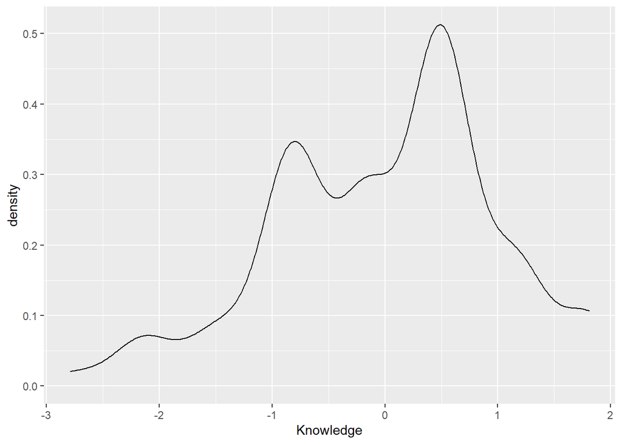

```r
ggplot(as.data.frame(model$construct_scores), aes(`Knowledge`)) +
  geom_density()
```

```r
# Response Beliefs
shapiro.test(model$construct_scores[,"Response Beliefs"])
```

```
##
##  Shapiro-Wilk normality test
##
## data:  model$construct_scores[, "Response Beliefs"]
## W = 0.91197, p-value = 3.892e-15
```

```r
lillie.test(model$construct_scores[,"Response Beliefs"])
```

```
##
##  Lilliefors (Kolmogorov-Smirnov) normality test
##
## data:  model$construct_scores[, "Response Beliefs"]
## D = 0.091614, p-value = 2.964e-09
```

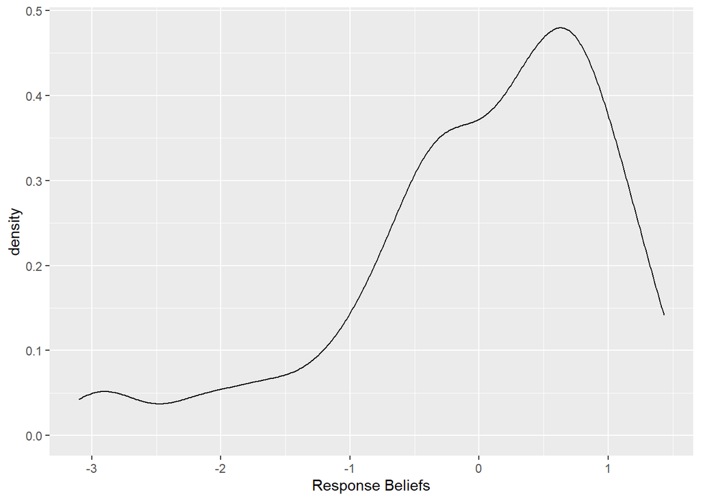

```r
ggplot(as.data.frame(model$construct_scores), aes(`Response Beliefs`)) +
  geom_density()
```

```r
# Personal Moral Norm
shapiro.test(model$construct_scores[,"Personal Moral Norm"])
```

```
##
##  Shapiro-Wilk normality test
##
## data:  model$construct_scores[, "Personal Moral Norm"]
## W = 0.75143, p-value < 2.2e-16
```

```r
lillie.test(model$construct_scores[,"Personal Moral Norm"])
```

```
##
##  Lilliefors (Kolmogorov-Smirnov) normality test
##
## data:  model$construct_scores[, "Personal Moral Norm"]
## D = 0.22799, p-value < 2.2e-16
```

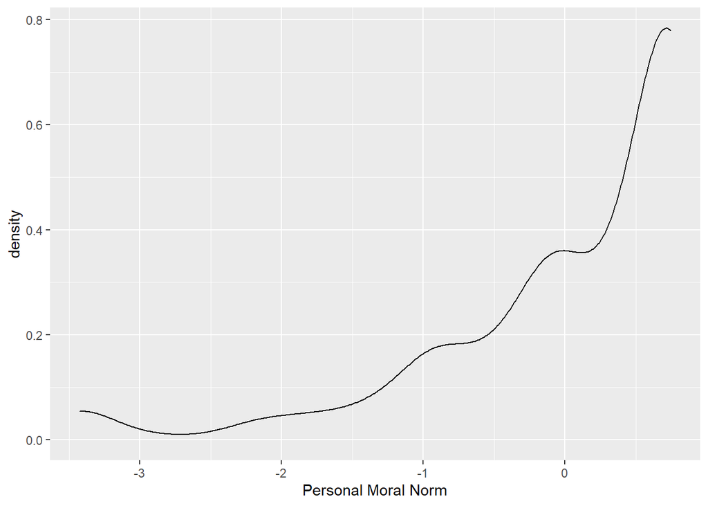

```r
ggplot(as.data.frame(model$construct_scores), aes(`Personal Moral Norm`)) +
  geom_density()
```

```r
# Descriptive Norm
shapiro.test(model$construct_scores[,"Descriptive Norm"])
```

```
##
##  Shapiro-Wilk normality test
##
## data:  model$construct_scores[, "Descriptive Norm"]
## W = 0.85193, p-value < 2.2e-16
```

```r
lillie.test(model$construct_scores[,"Descriptive Norm"])
```

```
##
##  Lilliefors (Kolmogorov-Smirnov) normality test
##
## data:  model$construct_scores[, "Descriptive Norm"]
## D = 0.1695, p-value < 2.2e-16
```

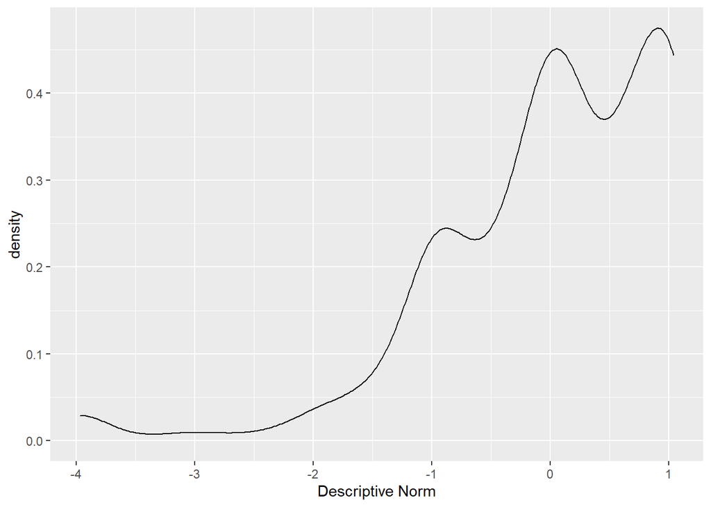

```r
ggplot(as.data.frame(model$construct_scores), aes(`Descriptive Norm`)) +
  geom_density()
```

All independent (or endogenous) variables are non-normally distributed. Therefore, the Gaussian Copula approach can be used for all of them.

# Regression of Response Beliefs on Distrusting Beliefs and Knowledge

```r
# Define Variables for easy access
KN <- model$construct_scores[,"Knowledge"]
DI <- model$construct_scores[,"Distrusting Beliefs"]
RB <- model$construct_scores[,"Response Beliefs"]

# Define number of bootstraps: 10.000 for reporting, 100 for testing
bootrounds <- 10000

# Estimate regression model
rbmodel <- lm(RB ~ DI + KN)
summary(rbmodel)
```

```
##
## Call:
## lm(formula = RB ~ DI + KN)
##
## Residuals:
##      Min       1Q   Median       3Q      Max
## -2.44077 -0.38952  0.01924  0.41966  2.07873
##
## Coefficients:
##               Estimate Std. Error t value Pr(>|t|)
## (Intercept)  6.986e-17  3.262e-02   0.000  1.00000
## DI          -6.990e-01  3.446e-02 -20.282  < 2e-16 ***
## KN           1.003e-01  3.446e-02   2.911  0.00379 **
## ---
## Signif. codes:  0 '***' 0.001 '**' 0.01 '*' 0.05 '.' 0.1 ' ' 1
##
## Residual standard error: 0.6773 on 428 degrees of freedom
## Multiple R-squared:  0.5434, Adjusted R-squared:  0.5413
## F-statistic: 254.7 on 2 and 428 DF,  p-value: < 2.2e-16
```

```r
bootrb <- Boot(rbmodel, R=bootrounds)
summary(bootrb)
```

```
##
## Number of bootstrap replications R = 10000
##                original   bootBias   bootSE     bootMed
## (Intercept)  6.9863e-17 0.00078590 0.032916  0.00094108
## DI          -6.9899e-01 0.00091378 0.039024 -0.69867797
## KN           1.0032e-01 0.00011942 0.035980  0.09977845
```

```r
# Make base df
rbdf <- data.frame(Construct = c("Distrusting Beliefs", "Knowledge", "Copula Distrusting Beliefs", "Copula Knowledge"),
                   Original.Model.Value = c(summary(bootrb)[2:3,5],NA,NA),
                   Original.Model.p = c(bootSig(model$data, bootrb, 2, 0)[2:3],NA,NA)
)

# Calculate copulas for independent variables
KN_star <- createCopula(KN)
DI_star <- createCopula(DI)


# Calculate results with copula for Distrusting Beliefs
# Input is regular model + copula + 0
copuladirb <- lm(RB ~ DI + KN + DI_star + 0)
summary(copuladirb)
```

```
##
## Call:
## lm(formula = RB ~ DI + KN + DI_star + 0)
##
## Residuals:
##      Min       1Q   Median       3Q      Max
## -2.46094 -0.39531  0.01636  0.41390  2.14374
##
## Coefficients:
##         Estimate Std. Error t value Pr(>|t|)
## DI      -0.90571    0.12451  -7.274 1.67e-12 ***
## KN       0.09573    0.03445   2.779  0.00569 **
## DI_star  0.18588    0.10761   1.727  0.08482 .
## ---
## Signif. codes:  0 '***' 0.001 '**' 0.01 '*' 0.05 '.' 0.1 ' ' 1
##
## Residual standard error: 0.675 on 428 degrees of freedom
## Multiple R-squared:  0.5466, Adjusted R-squared:  0.5434
## F-statistic:   172 on 3 and 428 DF,  p-value: < 2.2e-16
```

```r
# Bootstrap Standard Errors
bootcopuladirb <- Boot(copuladirb, R=bootrounds)
summary(bootcopuladirb)
```

```
##
## Number of bootstrap replications R = 10000
##          original    bootBias   bootSE   bootMed
## DI      -0.905710 -0.00885886 0.169476 -0.910420
## KN       0.095731 -0.00037873 0.035846  0.095363
## DI_star  0.185879  0.01093579 0.151055  0.191206
```

```r
# Calculate corrected p-values based on bootstrapped standard errors
# Input is data, bootstrapped results, number of independent variables, number of copulas
bootSig(model$data, bootcopuladirb, 2,1)
```

```
## [1] 1.481344e-07 7.860213e-03 2.191720e-01
```

```r
# Attach to df
rbdf <- rbdf %>% cbind(
  DI.Co.Model.Value = c(summary(bootcopuladirb)[1:3,5], NA),
  DI.Co.Model.p = c(bootSig(model$data, bootcopuladirb, 2,1), NA)
)

# Calculate results with copula for Knowledge
# Input is regular model + copula + 0
copulaknrb <- lm(RB ~ DI + KN + KN_star + 0)
summary(copulaknrb)
```

```
##
## Call:
## lm(formula = RB ~ DI + KN + KN_star + 0)
##
## Residuals:
##      Min       1Q   Median       3Q      Max
## -2.43145 -0.36500  0.03549  0.42899  2.08130
##
## Coefficients:
##         Estimate Std. Error t value Pr(>|t|)
## DI      -0.69549    0.03461 -20.095   <2e-16 ***
## KN       0.15204    0.06301   2.413   0.0162 *
## KN_star -0.03722    0.03798  -0.980   0.3277
## ---
## Signif. codes:  0 '***' 0.001 '**' 0.01 '*' 0.05 '.' 0.1 ' ' 1
##
## Residual standard error: 0.6765 on 428 degrees of freedom
## Multiple R-squared:  0.5444, Adjusted R-squared:  0.5412
## F-statistic: 170.5 on 3 and 428 DF,  p-value: < 2.2e-16
```

```r
# Bootstrap Standard Errors
bootcopulaknrb <- Boot(copulaknrb, R=bootrounds)
summary(bootcopulaknrb)
```

```
##
## Number of bootstrap replications R = 10000
##          original   bootBias   bootSE   bootMed
## DI      -0.695488 8.6413e-04 0.037620 -0.695527
## KN       0.152038 8.8305e-05 0.067495  0.152853
## KN_star -0.037221 3.3248e-04 0.037256 -0.037148
```

```r
# Calculate corrected p-values based on bootstrapped standard errors
# Input is data, bootstrapped results, number of independent variables, number of copulas
bootSig(model$data, bootcopulaknrb, 2,1)
```

```
## [1] 1.735680e-56 2.479254e-02 3.183296e-01
```

```r
# Attach to df
rbdf <- rbdf %>% cbind(
  KN.Co.Model.Value = c(summary(bootcopulaknrb)[1:2,5], NA, summary(bootcopulaknrb)[3,5]),
  KN.Co.Model.p = c(bootSig(model$data, bootcopulaknrb, 2,1)[1:2], NA, bootSig(model$data, bootcopulaknrb, 3,1)[3])
)

# Calculate results with copula for both DI and KN
# Input is regular model + copula + 0
copuladiknrb <- lm(RB ~ DI + KN + DI_star + KN_star + 0)
summary(copuladiknrb)
```

```
##
## Call:
## lm(formula = RB ~ DI + KN + DI_star + KN_star + 0)
##
## Residuals:
##      Min       1Q   Median       3Q      Max
## -2.45117 -0.36938  0.03546  0.42466  2.15231
##
## Coefficients:
##         Estimate Std. Error t value Pr(>|t|)
## DI      -0.91865    0.12491  -7.354 9.88e-13 ***
## KN       0.15883    0.06294   2.524   0.0120 *
## DI_star  0.20138    0.10833   1.859   0.0637 .
## KN_star -0.04569    0.03815  -1.198   0.2317
## ---
## Signif. codes:  0 '***' 0.001 '**' 0.01 '*' 0.05 '.' 0.1 ' ' 1
##
## Residual standard error: 0.6746 on 427 degrees of freedom
## Multiple R-squared:  0.5481, Adjusted R-squared:  0.5438
## F-statistic: 129.5 on 4 and 427 DF,  p-value: < 2.2e-16
```

```r
# Bootstrap Standard Errors
bootcopuladiknrb <- Boot(copuladiknrb, R=bootrounds)
summary(bootcopuladiknrb)
```

```
##
## Number of bootstrap replications R = 10000
##          original   bootBias   bootSE   bootMed
## DI      -0.918653 -0.0099675 0.166951 -0.927549
## KN       0.158831 -0.0028054 0.067056  0.156034
## DI_star  0.201377  0.0122440 0.147870  0.207014
## KN_star -0.045691  0.0019046 0.037768 -0.043827
```

```r
# Calculate corrected p-values based on bootstrapped standard errors
# Input is data, bootstrapped results, number of independent variables, number of copulas
bootstrappedSignificance(model$data, bootcopuladiknrb, 2, 2)
```

```
## Pr(>|t|) DI :  6.474231e-08
## Pr(>|t|) KN :  0.01829977
## Pr(>|t|) DI_star :  0.1739622
## Pr(>|t|) KN_star :  0.2270264
```

```r
# Attach to df
rbdf <- rbdf %>% cbind(
  DIKN.Co.Model.Value = c(summary(bootcopuladiknrb)[1:4,5]),
  DIKN.Co.Model.p = c(bootSig(model$data, bootcopuladiknrb, 2, 2))
)
datatable(rbdf) %>%
  formatRound(-1,
              digits = 3)
```

|  | Construct | Original.Model.Value | Original.Model.p | DI.Co.Model.Value | DI.Co.Model.p | KN.Co.Model.Value | KN.Co.Model.p | DIKN.Co.Model.Value | DIKN.Co.Model.p |
| --- | --- | --- | --- | --- | --- | --- | --- | --- | --- |
| 1 | Distrusting Beliefs | -0.698677974309007 | 6.01150241815155e-54 | -0.910420121681768 | 1.4813441280923e-07 | -0.695526756844373 | 1.73567980874393e-56 | -0.927549486150988 | 6.47423087099847e-08 |
| 2 | Knowledge | 0.0997784533267723 | 0.00553398486514762 | 0.0953626542406344 | 0.00786021259101867 | 0.152853410275384 | 0.0247925437388382 | 0.156034321420723 | 0.0182997721395103 |
| 3 | Copula Distrusting Beliefs |  |  | 0.191205809924814 | 0.219171962302172 |  |  | 0.207013597403648 | 0.173962169602619 |
| 4 | Copula Knowledge |  |  |  |  | -0.0371484086426907 | 0.318330935456423 | -0.0438265455074955 | 0.227026410739094 |

Neither the Distrusting Beliefs nor the Knowledge Copula is significant, indicating that there is no hidden endogeneity in the regression of Response Beliefs on its predictors.

# Regression of Behavioral Intention on its predictors

```r
# Define Variables for easy access
BI <- model$construct_scores[,"Behavioral Intention"]
PN <- model$construct_scores[,"Personal Moral Norm"]
DN <- model$construct_scores[,"Descriptive Norm"]

# Define number of bootstraps: 10.000 for reporting, 100 for testing
bootrounds <- 10000

# Estimate regression model
bimodel <- lm(BI ~ RB  + PN + DN)
summary(bimodel)
```

```
##
## Call:
## lm(formula = BI ~ RB + PN + DN)
##
## Residuals:
##      Min       1Q   Median       3Q      Max
## -2.38471 -0.31067  0.02294  0.34671  2.88678
##
## Coefficients:
##               Estimate Std. Error t value Pr(>|t|)
## (Intercept) -4.405e-16  2.768e-02   0.000 1.000000
## RB           5.290e-01  4.562e-02  11.595  < 2e-16 ***
## PN           2.319e-01  4.664e-02   4.972 9.61e-07 ***
## DN           1.328e-01  3.833e-02   3.464 0.000585 ***
## ---
## Signif. codes:  0 '***' 0.001 '**' 0.01 '*' 0.05 '.' 0.1 ' ' 1
##
## Residual standard error: 0.5746 on 427 degrees of freedom
## Multiple R-squared:  0.6722, Adjusted R-squared:  0.6699
## F-statistic: 291.8 on 3 and 427 DF,  p-value: < 2.2e-16
```

```r
bootbi <- Boot(bimodel, R=bootrounds)
summary(bootbi)
```

```
##
## Number of bootstrap replications R = 10000
##                original    bootBias   bootSE     bootMed
## (Intercept) -4.4047e-16 -0.00049380 0.027524 -0.00081847
## RB           5.2897e-01 -0.00367362 0.052790  0.52468457
## PN           2.3189e-01  0.00299788 0.064872  0.23517147
## DN           1.3277e-01  0.00076286 0.057805  0.13365437
```

```r
# Make base df
bidf <- data.frame(Construct = c("Response Beliefs", "Personal Moral Norm", "Descriptive Norm", "Copula Response Beliefs", "Copula Personal Moral Norm", "Copula Descriptive Norm"),
                   Original.Model.Value = c(summary(bootbi)[2:4,5],NA,NA,NA),
                   Original.Model.p = c(bootSig(model$data, bootbi, 3, 0)[2:4],NA,NA,NA)
)

# Calculate copulas for independent variables - already happened
RB_star <- createCopula(RB)
PN_star <- createCopula(PN)
DN_star <- createCopula(DN)

# Calculate results with copula for Response Beliefs
# Input is regular model + copula + 0
copularbbi <- lm(BI ~ RB + PN + DN + RB_star + 0)
summary(copularbbi)
```

```
##
## Call:
## lm(formula = BI ~ RB + PN + DN + RB_star + 0)
##
## Residuals:
##      Min       1Q   Median       3Q      Max
## -2.39445 -0.30939  0.04196  0.33699  2.89273
##
## Coefficients:
##         Estimate Std. Error t value Pr(>|t|)
## RB       0.59029    0.07212   8.185 3.18e-15 ***
## PN       0.22134    0.04756   4.654 4.35e-06 ***
## DN       0.13436    0.03830   3.508 0.000499 ***
## RB_star -0.05292    0.04825  -1.097 0.273372
## ---
## Signif. codes:  0 '***' 0.001 '**' 0.01 '*' 0.05 '.' 0.1 ' ' 1
##
## Residual standard error: 0.5738 on 427 degrees of freedom
## Multiple R-squared:  0.6731, Adjusted R-squared:   0.67
## F-statistic: 219.8 on 4 and 427 DF,  p-value: < 2.2e-16
```

```r
# Bootstrap Standard Errors
bootcopularbbi <- Boot(copularbbi)
summary(bootcopularbbi)
```

```
##
## Number of bootstrap replications R = 999
##         original    bootBias   bootSE   bootMed
## RB       0.59029 -0.00513536 0.072842  0.588312
## PN       0.22134  0.00432109 0.065400  0.223438
## DN       0.13436  0.00267593 0.057106  0.135967
## RB_star -0.05292 -0.00047573 0.032254 -0.051715
```

```r
# Calculate corrected p-values based on bootstrapped standard errors
# Input is data, bootstrapped results, number of independent variables, number of copulas
bootSig(model$data, bootcopularbbi, 3,1)
```

```
## [1] 5.697863e-15 7.794115e-04 1.908580e-02 1.015922e-01
```

```r
# Attach to df
bidf <- bidf %>% cbind(
  RB.Co.Model.Value = c(summary(bootcopularbbi)[,5], NA, NA),
  RB.Co.Model.p = c(bootSig(model$data, bootcopularbbi, 3,1), NA, NA)
)


# Calculate results with copula for Personal Moral Norm
# Input is regular model + copula + 0
copulapnbi <- lm(BI ~ RB + PN + DN + PN_star + 0)
summary(copulapnbi)
```

```
##
## Call:
## lm(formula = BI ~ RB + PN + DN + PN_star + 0)
##
## Residuals:
##      Min       1Q   Median       3Q      Max
## -2.39327 -0.31528 -0.00216  0.33542  2.84443
##
## Coefficients:
##         Estimate Std. Error t value Pr(>|t|)
## RB      0.527981   0.045613  11.575  < 2e-16 ***
## PN      0.216150   0.051512   4.196 3.31e-05 ***
## DN      0.132778   0.038304   3.466 0.000581 ***
## PN_star 0.007265   0.010123   0.718 0.473371
## ---
## Signif. codes:  0 '***' 0.001 '**' 0.01 '*' 0.05 '.' 0.1 ' ' 1
##
## Residual standard error: 0.5742 on 427 degrees of freedom
## Multiple R-squared:  0.6726, Adjusted R-squared:  0.6695
## F-statistic: 219.3 on 4 and 427 DF,  p-value: < 2.2e-16
```

```r
# Bootstrap Standard Errors
bootcopulapnbi <- Boot(copulapnbi)
summary(bootcopulapnbi)
```

```
##
## Number of bootstrap replications R = 999
##          original    bootBias   bootSE   bootMed
## RB      0.5279810 -0.00474203 0.053618 0.5225125
## PN      0.2161501  0.00805180 0.076706 0.2219413
## DN      0.1327784 -0.00017349 0.055479 0.1364853
## PN_star 0.0072646 -0.00067211 0.010556 0.0060701
```

```r
# Calculate corrected p-values based on bootstrapped standard errors
# Input is data, bootstrapped results, number of independent variables, number of copulas
bootSig(model$data, bootcopulapnbi, 3,1)
```

```
## [1] 9.503922e-21 5.058855e-03 1.712925e-02 4.917070e-01
```

```r
# Attach to df
bidf <- bidf %>% cbind(
  PN.Co.Model.Value = c(summary(bootcopulapnbi)[1:3,5], NA, summary(bootcopulapnbi)[4,5],  NA),
  PN.Co.Model.p = c(bootSig(model$data, bootcopulapnbi, 3,1)[1:3], NA, bootSig(model$data, bootcopulapnbi, 3,1)[4],NA)
)

# Calculate results with copula for Descriptive Norm
# Input is regular model + copula + 0
copuladnbi <- lm(BI ~ RB + PN + DN + DN_star + 0)
summary(copuladnbi)
```

```
##
## Call:
## lm(formula = BI ~ RB + PN + DN + DN_star + 0)
##
## Residuals:
##      Min       1Q   Median       3Q      Max
## -2.38322 -0.30837  0.03022  0.35207  2.90571
##
## Coefficients:
##         Estimate Std. Error t value Pr(>|t|)
## RB       0.52913    0.04562  11.598  < 2e-16 ***
## PN       0.23110    0.04674   4.945  1.1e-06 ***
## DN       0.14016    0.04804   2.918  0.00371 **
## DN_star -0.00384    0.01506  -0.255  0.79891
## ---
## Signif. codes:  0 '***' 0.001 '**' 0.01 '*' 0.05 '.' 0.1 ' ' 1
##
## Residual standard error: 0.5745 on 427 degrees of freedom
## Multiple R-squared:  0.6722, Adjusted R-squared:  0.6691
## F-statistic: 218.9 on 4 and 427 DF,  p-value: < 2.2e-16
```

```r
# Bootstrap Standard Errors
bootcopuladnbi <- Boot(copuladnbi)
summary(bootcopuladnbi)
```

```
##
## Number of bootstrap replications R = 999
##           original    bootBias   bootSE    bootMed
## RB       0.5291337 -0.00200408 0.051852  0.5253588
## PN       0.2311020  0.00249901 0.064631  0.2359563
## DN       0.1401585  0.00068773 0.079752  0.1405424
## DN_star -0.0038403 -0.00058414 0.017148 -0.0051004
```

```r
# Calculate corrected p-values based on bootstrapped standard errors
# Input is data, bootstrapped results, number of independent variables, number of copulas
bootSig(model$data, bootcopuladnbi, 3,1)
```

```
## [1] 5.083504e-22 3.893135e-04 7.956443e-02 8.229015e-01
```

```r
# Attach to df
bidf <- bidf %>% cbind(
  DN.Co.Model.Value = c(summary(bootcopuladnbi)[1:3,5], NA, NA, summary(bootcopuladnbi)[4,5]),
  DN.Co.Model.p = c(bootSig(model$data, bootcopuladnbi, 3,1)[1:3], NA,  NA, bootSig(model$data, bootcopuladnbi, 3,1)[4])
)


# Calculate results with copula for Response Beliefs and Personal Moral Norm
# Input is regular model + copula + 0
copularbpnbi <- lm(BI ~ RB + PN + DN + RB_star + PN_star + 0)
summary(copularbpnbi)
```

```
##
## Call:
## lm(formula = BI ~ RB + PN + DN + RB_star + PN_star + 0)
##
## Residuals:
##      Min       1Q   Median       3Q      Max
## -2.40995 -0.32466  0.02777  0.32179  2.83031
##
## Coefficients:
##         Estimate Std. Error t value Pr(>|t|)
## RB       0.60489    0.07345   8.235 2.22e-15 ***
## PN       0.19479    0.05390   3.614 0.000337 ***
## DN       0.13478    0.03830   3.519 0.000479 ***
## RB_star -0.06681    0.05004  -1.335 0.182541
## PN_star  0.01098    0.01049   1.047 0.295857
## ---
## Signif. codes:  0 '***' 0.001 '**' 0.01 '*' 0.05 '.' 0.1 ' ' 1
##
## Residual standard error: 0.5737 on 426 degrees of freedom
## Multiple R-squared:  0.6739, Adjusted R-squared:  0.6701
## F-statistic: 176.1 on 5 and 426 DF,  p-value: < 2.2e-16
```

```r
# Bootstrap Standard Errors
bootcopularbpnbi <- Boot(copularbpnbi)
summary(bootcopularbpnbi)
```

```
##
## Number of bootstrap replications R = 999
##          original    bootBias   bootSE   bootMed
## RB       0.604891 -0.00431830 0.074956  0.604606
## PN       0.194787  0.00395566 0.080439  0.193275
## DN       0.134782  0.00043594 0.057899  0.137091
## RB_star -0.066808  0.00078775 0.031801 -0.064258
## PN_star  0.010978 -0.00042658 0.011218  0.010680
```

```r
# Calculate corrected p-values based on bootstrapped standard errors
# Input is data, bootstrapped results, number of independent variables, number of copulas
bootSig(model$data, bootcopularbpnbi, 3,2)
```

```
## [1] 7.279111e-15 1.587190e-02 2.038668e-02 3.624210e-02 3.283165e-01
```

```r
# Attach to df
bidf <- bidf %>% cbind(
  RB.PN.Co.Model.Value = c(summary(bootcopularbpnbi)[,5], NA),
  RB.PN.Co.Model.p = c(bootSig(model$data, bootcopularbpnbi, 3,2), NA)
)

# Calculate results with copula for Response Beliefs and Subjective Norm
# Input is regular model + copula + 0
copularbdnbi <- lm(BI ~ RB + PN + DN + RB_star + DN_star + 0)
summary(copularbdnbi)
```

```
##
## Call:
## lm(formula = BI ~ RB + PN + DN + RB_star + DN_star + 0)
##
## Residuals:
##      Min       1Q   Median       3Q      Max
## -2.39468 -0.30938  0.04219  0.33691  2.89067
##
## Coefficients:
##          Estimate Std. Error t value Pr(>|t|)
## RB       0.590675   0.073588   8.027 9.83e-15 ***
## PN       0.221357   0.047616   4.649 4.46e-06 ***
## DN       0.133550   0.048431   2.758  0.00607 **
## RB_star -0.053271   0.049986  -1.066  0.28715
## DN_star  0.000426   0.015585   0.027  0.97821
## ---
## Signif. codes:  0 '***' 0.001 '**' 0.01 '*' 0.05 '.' 0.1 ' ' 1
##
## Residual standard error: 0.5744 on 426 degrees of freedom
## Multiple R-squared:  0.6731, Adjusted R-squared:  0.6693
## F-statistic: 175.4 on 5 and 426 DF,  p-value: < 2.2e-16
```

```r
# Bootstrap Standard Errors
bootcopularbdnbi <- Boot(copularbdnbi)
summary(bootcopularbdnbi)
```

```
##
## Number of bootstrap replications R = 999
##            original    bootBias   bootSE     bootMed
## RB       0.59067489 -0.00268549 0.076944  0.59140959
## PN       0.22135694  0.00241322 0.067443  0.22156327
## DN       0.13355030 -0.00079623 0.084281  0.13398939
## RB_star -0.05327102 -0.00012557 0.033160 -0.05186222
## DN_star  0.00042601 -0.00020504 0.018780  0.00065527
```

```r
# Calculate corrected p-values based on bootstrapped standard errors
# Input is data, bootstrapped results, number of independent variables, number of copulas
bootSig(model$data, bootcopularbdnbi, 3,2)
```

```
## [1] 1.132035e-13 1.115324e-03 1.138057e-01 1.089153e-01 9.819129e-01
```

```r
# Attach to df
bidf <- bidf %>% cbind(
  RB.DN.Co.Model.Value = c(summary(bootcopularbdnbi)[1:4,5], NA, summary(bootcopularbdnbi)[5,5]),
  RB.DN.Co.Model.p = c(bootSig(model$data, bootcopularbdnbi, 3,2)[1:4], NA, bootSig(model$data, bootcopularbdnbi, 3,2)[5])
)

# Calculate results with copula for Personal Moral Norm and Descriptive Norm
# Input is regular model + copula + 0
copulapndnbi <- lm(BI ~ RB + PN + DN + PN_star + DN_star + 0)
summary(copulapndnbi)
```

```
##
## Call:
## lm(formula = BI ~ RB + PN + DN + PN_star + DN_star + 0)
##
## Residuals:
##      Min       1Q   Median       3Q      Max
## -2.39397 -0.30718  0.00256  0.33902  2.88340
##
## Coefficients:
##         Estimate Std. Error t value Pr(>|t|)
## RB       0.52789    0.04563  11.568  < 2e-16 ***
## PN       0.20200    0.05465   3.697 0.000247 ***
## DN       0.15980    0.05170   3.091 0.002127 **
## PN_star  0.01247    0.01213   1.027 0.304780
## DN_star -0.01405    0.01805  -0.779 0.436668
## ---
## Signif. codes:  0 '***' 0.001 '**' 0.01 '*' 0.05 '.' 0.1 ' ' 1
##
## Residual standard error: 0.5745 on 426 degrees of freedom
## Multiple R-squared:  0.673,  Adjusted R-squared:  0.6692
## F-statistic: 175.4 on 5 and 426 DF,  p-value: < 2.2e-16
```

```r
# Bootstrap Standard Errors
bootcopulapndnbi <- Boot(copulapndnbi)
summary(bootcopulapndnbi)
```

```
##
## Number of bootstrap replications R = 999
##          original    bootBias   bootSE   bootMed
## RB       0.527888 -5.3908e-03 0.052250  0.522873
## PN       0.202004  2.0862e-03 0.086576  0.209043
## DN       0.159798  4.5325e-03 0.087640  0.166999
## PN_star  0.012466 -5.8975e-05 0.013383  0.012064
## DN_star -0.014050 -4.5383e-04 0.020805 -0.014649
```

```r
# Calculate corrected p-values based on bootstrapped standard errors
# Input is data, bootstrapped results, number of independent variables, number of copulas
bootSig(model$data, bootcopulapndnbi, 3,2)
```

```
## [1] 1.187536e-21 2.010016e-02 6.895364e-02 3.521433e-01 4.998467e-01
```

```r
# Attach to df
bidf <- bidf %>% cbind(
  PN.DN.Co.Model.Value = c(summary(bootcopulapndnbi)[1:3,5], NA, summary(bootcopulapndnbi)[4:5,5]),
  PN.DN.Co.Model.p = c(bootSig(model$data, bootcopulapndnbi, 3,2)[1:3], NA, bootSig(model$data, bootcopulapndnbi, 3,2)[4:5])
)


# Calculate results with copula for Response Beliefs, Personal Moral Norm and Descriptive Norm
# Input is regular model + copula + 0
copularbpndnbi <- lm(BI ~ RB + PN + DN + RB_star + PN_star + DN_star + 0)
summary(copularbpndnbi)
```

```
##
## Call:
## lm(formula = BI ~ RB + PN + DN + RB_star + PN_star + DN_star +
##     0)
##
## Residuals:
##      Min       1Q   Median       3Q      Max
## -2.40945 -0.30973  0.02584  0.32457  2.86155
##
## Coefficients:
##         Estimate Std. Error t value Pr(>|t|)
## RB       0.60000    0.07395   8.113 5.35e-15 ***
## PN       0.18511    0.05629   3.288  0.00109 **
## DN       0.15570    0.05177   3.007  0.00279 **
## RB_star -0.06262    0.05056  -1.239  0.21615
## PN_star  0.01480    0.01227   1.206  0.22850
## DN_star -0.01094    0.01821  -0.601  0.54813
## ---
## Signif. codes:  0 '***' 0.001 '**' 0.01 '*' 0.05 '.' 0.1 ' ' 1
##
## Residual standard error: 0.5741 on 425 degrees of freedom
## Multiple R-squared:  0.6742, Adjusted R-squared:  0.6696
## F-statistic: 146.6 on 6 and 425 DF,  p-value: < 2.2e-16
```

```r
# Bootstrap Standard Errors
bootcopularbpndnbi <- Boot(copularbpndnbi)
summary(bootcopularbpndnbi)
```

```
##
## Number of bootstrap replications R = 999
##          original    bootBias   bootSE   bootMed
## RB       0.600001  3.1847e-05 0.078073  0.597041
## PN       0.185106 -2.4260e-03 0.085794  0.184432
## DN       0.155702  3.6576e-03 0.087162  0.160718
## RB_star -0.062624 -1.9341e-03 0.034033 -0.061551
## PN_star  0.014797  3.3460e-04 0.013669  0.015044
## DN_star -0.010944 -3.1749e-04 0.021177 -0.011827
```

```r
# Calculate corrected p-values based on bootstrapped standard errors
# Input is data, bootstrapped results, number of independent variables, number of copulas
bootSig(model$data, bootcopularbpndnbi, 3,3)
```

```
## [1] 1.072648e-13 3.152408e-02 7.475433e-02 6.645228e-02 2.796398e-01
## [6] 6.055913e-01
```

```r
# Attach to df
bidf <- bidf %>% cbind(
  RB.PN.DN.Co.Model.Value = c(summary(bootcopularbpndnbi)[,5]),
  RB.PN.DN.Co.Model.p = c(bootSig(model$data, bootcopularbpndnbi, 3,3))
)

datatable(bidf) %>%
  formatRound(-1,
              digits = 3)
```

|  | Construct | Original.Model.Value | Original.Model.p | RB.Co.Model.Value | RB.Co.Model.p | PN.Co.Model.Value | PN.Co.Model.p | DN.Co.Model.Value | DN.Co.Model.p | RB.PN.Co.Model.Value | RB.PN.Co.Model.p | RB.DN.Co.Model.Value | RB.DN.Co.Model.p | PN.DN.Co.Model.Value | PN.DN.Co.Model.p | RB.PN.DN.Co.Model.Value | RB.PN.DN.Co.Model.p |
| --- | --- | --- | --- | --- | --- | --- | --- | --- | --- | --- | --- | --- | --- | --- | --- | --- | --- |
| 1 | Response Beliefs | 0.524684571363433 | 2.29701004868334e-21 | 0.588312195159225 | 5.69786293104208e-15 | 0.522512488539205 | 9.50392209321542e-21 | 0.525358801559068 | 5.08350390404585e-22 | 0.604605792333415 | 7.27911088499145e-15 | 0.591409587111571 | 1.13203538596398e-13 | 0.522872851892012 | 1.18753644044251e-21 | 0.597040710805292 | 1.07264818284599e-13 |
| 2 | Personal Moral Norm | 0.235171470994205 | 0.000390870503218844 | 0.223438121553123 | 0.000779411503352301 | 0.221941270220818 | 0.00505885474309825 | 0.235956274733032 | 0.000389313525290019 | 0.193275332185047 | 0.0158718973196041 | 0.221563267717006 | 0.00111532374724236 | 0.209042929614409 | 0.0201001572358737 | 0.184432458046865 | 0.0315240806612317 |
| 3 | Descriptive Norm | 0.133654365781164 | 0.0221062116358851 | 0.135967420261725 | 0.0190858024484174 | 0.136485307925313 | 0.0171292517232615 | 0.140542369439832 | 0.0795644274058566 | 0.137090660551046 | 0.0203866814726851 | 0.133989393795938 | 0.113805659030635 | 0.166999377026445 | 0.0689536377657312 | 0.160718388229635 | 0.0747543311515867 |
| 4 | Copula Response Beliefs |  |  | -0.0517147996028038 | 0.101592206965847 |  |  |  |  | -0.0642584726977496 | 0.0362421043882407 | -0.0518622225775193 | 0.108915323399206 |  |  | -0.0615507916649693 | 0.0664522766679361 |
| 5 | Copula Personal Moral Norm |  |  |  |  | 0.00607012402561579 | 0.491706962314076 |  |  | 0.010680447542118 | 0.328316546933537 |  |  | 0.0120635110658291 | 0.352143347484119 | 0.0150439662736118 | 0.279639821323051 |
| 6 | Copula Descriptive Norm |  |  |  |  |  |  | -0.00510039882640072 | 0.822901509634019 |  |  | 0.000655272948362355 | 0.981912888430139 | -0.0146485352286516 | 0.499846656504771 | -0.0118268846459845 | 0.605591343951698 |

The copula will be integrated in the final model to improve the model.